# Linear Model 2: The *F* Awakens

Week 09

Dr Jenny Terry

[figure not shown]

## Looking Ahead (and Behind)

- The story so far…
  - Fundamentals of NHST & Statistical Tests
  - The Linear Model - Using the Equation of a Line to Make Predictions
- This week:
  - The Linear Model - **Evaluating the Model**
- Coming up:
  - The Linear Model - Models with Multiple Predictors
  - Questionable Research Practices

## Today’s Objectives

First, a recap:

- Linear model
  - Recap of how we can use the model to make **predictions**

After this lecture, you will (begin to) understand:

- Evaluating **model fit** (conceptually) with $R^2$ and the $F$**-statistic**
- Evaluating the **statistical significance** of the prediction with *p*-values and **CI**s

**Talk to Me!**

Open the Lecture Google Doc: bit.ly/AnD_lecture_09

# Using the Linear Model to Make Predictions (Recap)

## The Linear Model as a Statistical Model

Models take **sample data** and use **known mathematical properties** of the world around us to make **predictions** about the **population** from which our sample came from.

**Vocabulary: The General Model Equation**

A conceptual representation of all statistical models, with the following form:

$$outcome = model + error$$

**Vocabulary: The Linear Model Equation**

A particularly common type of statistical model, with the following form:

$$y_{i} = b_{0} + b_{1}\times x_{1i} + e_{i}$$

## The Linear Model Equation

$$y_{i} = b_{0} + b_{1}\times x_{1i} + e_{i}$$

| **Term** | **Meaning** |
| --- | --- |
| $y_i$ = | The predicted outcome ($y$) for an individual’s score ($i$) is equal to (or, is predicted by)… |
| $b_0$ | … the value of beta-zero (the model’s intercept)… |
| + | … plus… |
| $b_1$ | … the value of beta-one (the model’s slope)… |
| $\times$ | … multiplied by… |
| $x_{1i}$ | … the hypothetical value of the predictor ($x_1$) for an individual ($i$)… |
| $+$ | … plus… |
| $e_i$ | … the (unknowable) error ($e$) for the individual’s actual score ($i$). |

## The Linear Model Equation

$$y_{i} = b_{0} + b_{1}\times x_{1i} + e_{i}$$

- $b_{0} + b_{1}\times x_{1i}$ is the model
- $b_0$ (intercept) is the value of $y$ when $x$ is 0
- $b_1$ (slope) is the change in $y$ for every unit change in $x$
- The model uses sample data to estimate $b_0$ and $b_1$ in the population
- Once we know $b_0$ and $b_1$, we can estimate $y_i$ (outcome) for any value of $x_{1i}$

# Evaluating our Model: Is it any Good?

## Statistical Models

- When we used the linear model last week, we were **making predictions** **about hypothetical individuals from a population** by extrapolating from a model based on a sample of data from that population
- In psychology, we don’t usually use it to make predictions as such, but we tend to focus on what $b_1$ (the slope) tells us about the **strength and** **direction of the relationship** between our predictor and outcome
- But, how do we know if what our model is telling us about $b_1$ is meaningful?
  - First, is the model itself any good?
    - $R^2$ and the $F$-statistic
  - Next, is the value of the slope ($b_1$) important?
    - *p*-values and confidence intervals

## The Simplest Model

- A good linear model should fit the data better than the **simplest possible model**
- The simplest model is the **null (aka, intercept-only) model** - where there is **no relationship** **between the predictor(s) and outcome**
- Here’s our linear model again: $y_{i} = b_{0} + b_{1}\times x_{1i} + e_{i}$
- If there is no relationship between the predictor and outcome then $b_1 = 0$
- If we replace $b_1$ with $0$ then we get: $y_i=b_0+0\times x_{1i} + e_i$
- But $0\times x_{1i} = 0$ so we can then drop $b_1\times x_{1i}$ from the equation to get: $y_i = b_0 + e_i$
- When there are no predictors, $b_0$ is the model (which is just the mean of $y$)
- So, a linear model with no predictors **predicts the** **outcome by the mean of the outcome**

## Mean Model Residuals

- The lines from each point to the mean represent the **distance between the sleep score of each participant and the mean sleep score for the sample** (aka the **residual error**)
- We can use these residuals to calculate the overall amount of error and, therefore, **variance** in our *mean* model

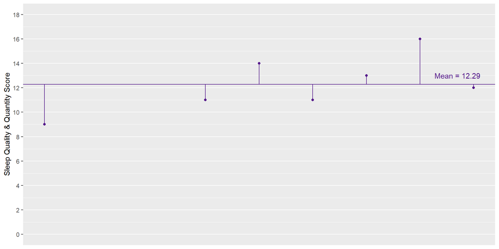

## Linear Model Residuals

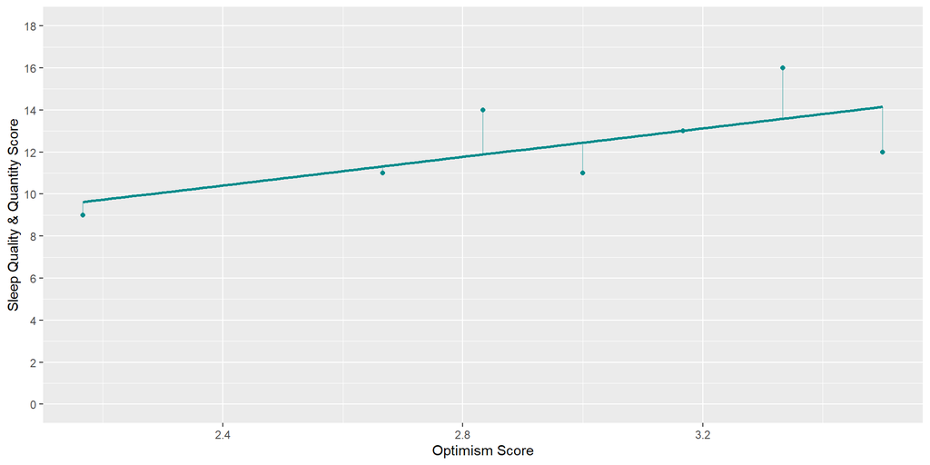

## Goodness of Fit with $R^2$

**Vocabulary: $R^2$**

$R^2$ = how much of the variance in the outcome is explained by the model

- In other words, do our predictors do a good job of explaining changes in the outcome?
- $R^2$ portions out the variance in the linear model from the mean model
- $R^2$ is a **Goodness of Fit** measure for linear models
- $R^2$ will appear in your output as a decimal, but is usually reported as a percentage on a **0 -100% scale**
  - e.g., “… the model explains $x$ % of the variance in the outcome…”
- The **higher the** $R^2$ **value, the better the model** (but, low values are not always a cause of concern)
- But, is that amount of variance sufficiently large that we would conclude the effect is meaningful in the population?

## The $F$-statistic

**Vocabulary: $F$-statistic**

$F$ = whether the variance explained significantly differs from zero

- The $F$**-statistic** also uses (a slightly different, but related) comparison of the amount of error in the mean model and the amount of error in your linear model
- So, using **null hypothesis significance testing** (NHST), we can get an associated *p*-value for our $F$-statistic

## NHST Recap

To get a *p*-value…

- We first obtain **data**, from which we calculate…
- A **test statistic** that represents the relationship of interest, which we compare to…
- The **distribution** of that test statistic under the null hypothesis (where there is no relationship) to get…
- The **probability** (*p*) of getting a test statistic **at least as large as the one we have if the null hypothesis is true** so that we can…
- **Evaluate** our competing hypotheses using a previously decided alpha ($\alpha$) level (usually 0.05)
- If our p-value is lower than $\alpha$, we say that is **statistically significant** and we **reject the null hypothesis**

## The $F$-statistic

- In this case, the $F$-statistic is our **test statistic** that represents the relationship of interest, which we compare to…
- The **distribution** of the $F$-statistic under the null hypothesis (where there is no relationship between the predictor and the outcome) to get…
- The **probability** (*p*) of getting **an** $F$**-statistic as large as the one we’ve observed if the null hypothesis is true**
- **Evaluate** our competing hypotheses using a previously decided $\alpha$ level (usually 0.05)
- If our p-value is lower than $\alpha$, we say that is **statistically significant** and **reject the null hypothesis**
- The *F*-statistic and it’s *p*-value will appear in your R output, so let’s have a quick look…

## Example: Predicting Better Sleep from Positive Psychology

#### Research Question

- Are positive psychology attributes (e.g., gratitude, optimism, mindfulness) associated with better sleep?

#### Operationalisation

- Predictor: Positive psychology attributes
- Outcome: Sleep quality & quantity
- Model: $Sleep_{i} = b_{0} + b_{1}\times PositivePsychology_{1i} + e_{i}$

## Is it a Good Model?

```
Call:
lm(formula = sleep ~ pos_psy, data = sleep_tib)

Residuals:
    Min      1Q  Median      3Q     Max
-12.526  -1.706   0.408   1.978   5.389

Coefficients:
            Estimate Std. Error t value Pr(>|t|)
(Intercept)   3.5202     1.1502   3.060  0.00239 **
pos_psy       2.2872     0.3149   7.262 2.74e-12 ***
---
Signif. codes:  0 '***' 0.001 '**' 0.01 '*' 0.05 '.' 0.1 ' ' 1

Residual standard error: 2.855 on 331 degrees of freedom
Multiple R-squared:  0.1374,    Adjusted R-squared:  0.1348
F-statistic: 52.74 on 1 and 331 DF,  p-value: 2.744e-12
```

- How much of the variance in sleep is accounted for by positive psychology attributes? 🤔
- Is the $F$-statistic statistically significant? 🤔
- What does this suggest about the fit of the model? 🤔

🤫[Scientific Notation Converter](https://www.calculatorsoup.com/calculators/math/scientific-notation-converter.php) 🤫

## Interim Summary

- How do we know if what our model is telling us about $b_1$ is important?
  - First, is the model itself any good?
    - $R^2$ and the $F$-statistic ✅
- Specifically, a good model will:
  - Fit the data better than the simplest possible model ($R^2$ & $F$-statistic)
  - Explain a lot of variance in the outcome ($R^2$)
  - Explain an amount of variance that significantly differs from zero ($F$-statistic)
- How do we know if what our model is telling us about $b_1$ is important?
  - Next, is the value of the slope ($b_1$) meaningful?
    - *p*-values and confidence intervals

# Evaluating our Model: Is $b_1$ Meaningful?

## What is so Special about $b_1$?

- It is a **(parameter) *estimate*** of the true relationship between our variables in the population
- When we’ve been using the linear model so far, we’ve been making **predictions**
- In psychology, we don’t usually make predictions as such, but instead interpret what $b_1$ tells us about the **strength and** **direction of the relationship** between our predictor and outcome
- In other words, we treat $b_1$ as an **effect size**

## $b_1$ as an Effect Size

[interactive chart not shown]

## Example: Predicting Better Sleep from Positive Psychology

#### Research Question

- Are positive psychology attributes (e.g., gratitude, optimism, mindfulness) associated with better sleep?

#### Operationalisation

- Predictor: Positive psychology attributes
- Outcome: Sleep quality & quantity
- Model: $Sleep_{i} = b_{0} + b_{1}\times PositivePsychology_{1i} + e_{i}$

#### Hypotheses

- What is the null hypothesis? 🤔
- What is the alternative hypothesis? 🤔

## Hypotheses

#### Null Hypothesis

- No relationship between $x$ and $y$
- No relationship between positive psychology and sleep
- $b_1 = 0$

#### Alternative Hypothesis

- Relationship between $x$ and $y$
- Relationship between positive psychology and sleep
- $b_1 \ne 0$

## Significance of *b*<sub>1</sub>

- Is our estimate of *b*<sub>1</sub> **different** **enough** **from 0** to believe that it is not 0 in the population?
- We - well, R - tests this with **NHST**.
- First, we need a test statistic, so we…:

1) Scale the estimate of *b*<sub>1</sub> by its **standard error** (variation of estimates)

**ChallengR!**

What do you get when you divide a normally distributed value by its standard error? 🤔

## Calculating the Test Statistic for $b_1$

1) Scale the estimate of *b*<sub>1</sub> by its **standard error** (variation of estimates):

$$\frac{b_{1}}{SE_{b_1}} = t$$

2) Compare the value of *t* to the *t*-distribution to get *p*, just as we’ve seen before

3) If *p* is smaller than our chosen $\alpha$ level, our predictor is considered to be statistically significant

## Confidence Intervals (Recap)

- We can also compute a **confidence interval** (CI) for $b_1$ (see Lecture 3)
- *Assuming* that our sample is **one of the 95% of samples producing confidence intervals that contain the population value**, then the population value for the estimate of interest falls somewhere between the lower limit the upper limit of the interval we’ve computed for our sample
- But, **we cannot know if our sample is one of the 95%** producing a confidence interval that contains the population value
- So, **they do NOT mean we can be 95% confident** that the result lies between the lower and upper limits of our computed interval

## Confidence Intervals for $b_1$

- CIs are useful as a **measure of uncertainty** in our estimate
  - **Is there a relatively large difference between the upper and lower limits?**
    - If yes, there is a large amount of uncertainty
    - If no, there is a small amount of uncertainty
  - For example:
    - 95% CI = [1.28, 10.34] is a wide CI with a large amount of uncertainty
    - 95% CI = [1.28, 1.34] is a narrow CI with a small amount of uncertainty

## Confidence Intervals for $b_1$

- CIs can also tell us about the **statistical** **significance** of $b_1$
  - **Does the CI cross (contain) 0?**
    - If it does, and our sample contains the population value, it is possible the population value is 0.
    - If it doesn’t, and our sample contains the population value, it is unlikely the population value is 0.
  - For example:
    - 95% CI = [-1.28, 1.34] crosses 0 *(tip: look for a negative sign)*
    - 95% CI = [1.28, 1.34] does not cross 0

## Is $b_1$ (Statistically) Significant?

```
Call:
lm(formula = sleep ~ pos_psy, data = sleep_tib)

Residuals:
    Min      1Q  Median      3Q     Max
-12.526  -1.706   0.408   1.978   5.389

Coefficients:
            Estimate Std. Error t value Pr(>|t|)
(Intercept)   3.5202     1.1502   3.060  0.00239 **
pos_psy       2.2872     0.3149   7.262 2.74e-12 ***
---
Signif. codes:  0 '***' 0.001 '**' 0.01 '*' 0.05 '.' 0.1 ' ' 1

Residual standard error: 2.855 on 331 degrees of freedom
Multiple R-squared:  0.1374,    Adjusted R-squared:  0.1348
F-statistic: 52.74 on 1 and 331 DF,  p-value: 2.744e-12
```

- Is the *p*-value associated with $b_1$ statistically significant? 🤔

🤫[Scientific Notation Converter](https://www.calculatorsoup.com/calculators/math/scientific-notation-converter.php) 🤫

## Where’s the CI?!

| term | estimate | std.error | statistic | p.value | conf.low | conf.high |
| --- | --- | --- | --- | --- | --- | --- |
| (Intercept) | 3.520190 | 1.1502372 | 3.060403 | 0.0023911 | 1.257493 | 5.782887 |
| pos_psy | 2.287165 | 0.3149414 | 7.262193 | 0.0000000 | 1.667626 | 2.906704 |

- Is there much uncertainty in the estimate of $b_1$, according to the CI? 🤔
- What can we infer about the statistical significance of $b_1$ from the CI? 🤔

## $b_1$ as an Effect Size

```
Call:
lm(formula = sleep ~ pos_psy, data = sleep_tib)

Residuals:
    Min      1Q  Median      3Q     Max
-12.526  -1.706   0.408   1.978   5.389

Coefficients:
            Estimate Std. Error t value Pr(>|t|)
(Intercept)   3.5202     1.1502   3.060  0.00239 **
pos_psy       2.2872     0.3149   7.262 2.74e-12 ***
---
Signif. codes:  0 '***' 0.001 '**' 0.01 '*' 0.05 '.' 0.1 ' ' 1

Residual standard error: 2.855 on 331 degrees of freedom
Multiple R-squared:  0.1374,    Adjusted R-squared:  0.1348
F-statistic: 52.74 on 1 and 331 DF,  p-value: 2.744e-12
```

- The value of *b*<sub>1</sub> is also a useful and interpretable value by itself
- It can tell us the **direction** of the relationship between the predictor and outcome
  - Is the direction of the relationship positive or negative? 🤔
- It can also tell us the **strength** of the relationship between the predictor and outcome
  - More on this next week!

## Putting It All Together

- $R^2$ tells us the percentage of outcome variance our model explains
- The $F$-statistic and its associated *p*-value tells is whether the amount of variance explained is significantly different from 0
- We can also get an associated *p*-value and confidence interval for $b_1$ that tells us whether $b_1$ is significantly different from 0
- We can also use the confidence interval as a measure of uncertainty
- $b_1$ is also an effect size that tells us the strength and direction of the relationship between the predictor and the outcome

**Reporting Results in APA Style**

The model explained a statistically significant proportion of the variance in sleep quality and quantity, $R^2$ = 13.7%, *F*(1, 331) = 52.74, *p* < 0.001. Positive psychology attributes positively and statistically significantly predicted sleep quality and quantity, $b_1$ = 2.29 [1.67, 2.91], *t*(331) = 7.26, *p* < 0.001.

## Further Support

- The linear model will be crucial for the rest of your degree, so if that was a bit of a blur to you, it’s highly recommended that you spend some time working through it slowly, until it clicks.
- Here are some recommendations for extra sources of support:
  - [Statistics by Jim blog/videos](https://statisticsbyjim.com/regression/linear-regression-equation/) (beginner)
  - [Khan Academy’s introduction to linear equations](https://www.khanacademy.org/math/algebra/x2f8bb11595b61c86:linear-equations-graphs) (beginner)
  - [Learning Statistics with R](https://learningstatisticswithr.com/lsr-0.6.pdf) - see Section V, Chapter 15, Linear Regression (intermediate)
  - [Andy Field’s YouTube channel](https://youtu.be/7cSArk7tU4w?si=XBl2CORBn2CMmvZd) (intermediate)
  - [CenterStat YouTube channel](https://youtube.com/playlist?list=PLQGe6zcSJT0V4xC1NDyQePkyxUj8LWLnD&si=BQMJwNC9JDeINAwk) (advanced)
- They cover a few points we don’t get into on AnD (especially the intermediate and advanced stuff), but these are the some of the clearest explanations of the linear model and associated concepts I’ve ever encountered, so I highly recommend them.